# Assignment 4 - Jonas Gstöttenmayr

### Answers are in the same markdown cell as the questions

## Exercise 1 Static vs Contextual Embeddings

In this assignment, you will explore the differences between static word embeddings and contextual embeddings using the BERT model. You will extract embeddings from different layers, apply t-SNE visualization, and analyze how meaning shifts with context.

**Tasks:**

1. Load BERT tokenizer and model
2. Prepare a list of example sentences
3. Extract static embeddings (embedding layer)
4. Extract contextual embeddings (final hidden layer)
5. Run t-SNE on both sets of embeddings
6. Visualize and compare the representations prepare this for the presentation in the exercise.
7. Research if/when the static and contextual embeddings are still comparable to each other.

**Deliverables:** A notebook with embedding extraction, visualizations, analysis and interpretation.

**Answer**

Questions 7:

(situations when they have the same value)

- When the contextual meaning perfectly matches what the static one was trained on (unrealisitic). So when there is no context and only a single word.
- In the very first model layer before the transformer modifies the embeddings

(situation when comparing makes sense)

- to see how different the new contextual word is from the old
- to check if the contextual embedding actually worked (or is still the same stack one)
- when using NLP metrics to measure how well a model understands sementic meaning and can differentiate between synonyms and contexts

```python
import random
import torch

import pandas as pd
import numpy as np
import matplotlib.pyplot as plt

from transformers import BertTokenizer, BertModel
from sklearn.manifold import TSNE
```

```python
# Set a random seed
random_seed = 42
random.seed(random_seed)
```

```python
tokenizer = BertTokenizer.from_pretrained("bert-base-uncased")
model = BertModel.from_pretrained("bert-base-uncased", output_hidden_states=True)
```

[output not shown]

**AI usage:**

Prompt: 4 short example sentences in pairs of 2 for their topics give in in the form of a python list with comments of the topics, ensure that the sentences of the same topic share a words of their topics in common. Common words should appear between sentence but with different meaning to showcase the difference between static and dynamic embeddings

```python
sentences = [
    # bank
    "The bank handles all my monthly savings.",
    "The bank of the river.",

    # mouse
    "The mouse scurried across the kitchen floor.",
    "My computer mouse is lagging during the game."
]
```

```python
# Encode the text
inputs = tokenizer(sentences, return_tensors="pt", padding=True)

print(f"Tokens: {tokenizer.tokenize(sentences)}")
print(f"Input IDs: {inputs['input_ids']}")
# special:
# 101 -> [CLS]
# 102 -> [SEP]
# 0   -> [PAD]
print(f"Inputs: {inputs['attention_mask']}\n")
```

```
Tokens: ['the', 'bank', 'handles', 'all', 'my', 'monthly', 'savings', '.']
Input IDs: tensor([[  101,  1996,  2924, 16024,  2035,  2026,  7058, 10995,  1012,   102,
             0,     0],
        [  101,  1996,  2924,  1997,  1996,  2314,  1012,   102,     0,     0,
             0,     0],
        [  101,  1996,  8000,  8040,  3126, 11998,  2408,  1996,  3829,  2723,
          1012,   102],
        [  101,  2026,  3274,  8000,  2003,  2474, 12588,  2076,  1996,  2208,
          1012,   102]])
Inputs: tensor([[1, 1, 1, 1, 1, 1, 1, 1, 1, 1, 0, 0],
        [1, 1, 1, 1, 1, 1, 1, 1, 0, 0, 0, 0],
        [1, 1, 1, 1, 1, 1, 1, 1, 1, 1, 1, 1],
        [1, 1, 1, 1, 1, 1, 1, 1, 1, 1, 1, 1]])
```

```python
with torch.no_grad():
    outputs = model(**inputs)

# the first embeddings are the static inital static embeddings
static_embeddings = outputs.hidden_states[0]

bank_1 = static_embeddings[0, 2] # bank is 2nd word, adds a extra tocken in beginning so index 2
bank_2 = static_embeddings[1, 2]
print("Static banks equal: ", torch.equal(bank_1, bank_2))

# Last hidden states: [batch_size, seq_len, hidden_size]
dynamic_embeddings = outputs.last_hidden_state

# The vector for 'bank' in sentence 1 is not equal to 'bank' in sentence 2
bank_1 = dynamic_embeddings[0, 2]
bank_2 = dynamic_embeddings[1, 2]
print("Dynamic banks equal: ", torch.equal(bank_1, bank_2))
```

```
Static banks equal:  True
Dynamic banks equal:  False
```

```python
tokens = [["[CLS]"] + tokenizer.tokenize(sentence) + ["[SEP]"] for sentence in sentences]
for sentence in tokens:
    while len(sentence) < 12:
        sentence.append("[PAD]")
tokens = np.array(tokens).flatten()
tokens
```

```
array(['[CLS]', 'the', 'bank', 'handles', 'all', 'my', 'monthly',
       'savings', '.', '[SEP]', '[PAD]', '[PAD]', '[CLS]', 'the', 'bank',
       'of', 'the', 'river', '.', '[SEP]', '[PAD]', '[PAD]', '[PAD]',
       '[PAD]', '[CLS]', 'the', 'mouse', 'sc', '##ur', '##ried', 'across',
       'the', 'kitchen', 'floor', '.', '[SEP]', '[CLS]', 'my', 'computer',
       'mouse', 'is', 'la', '##gging', 'during', 'the', 'game', '.',
       '[SEP]'], dtype='<U8')
```

**AI usage**

prompt: i have an embedding vector consisting of 4 sentences with 12 tokens each and 768 dimensions per token, build me the visualisation with tsne for the entire embeddings please, it should show the original word in the embedding and use the sentence as the class, showcase using matplotlib

The output was the code which i modified to take axes and use cosine similarity

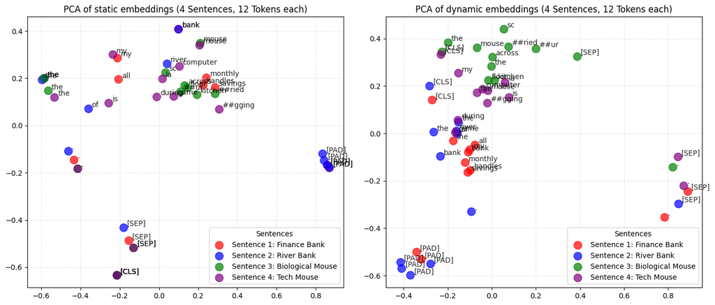

```python
from sklearn.decomposition import PCA

def plot_embedding(embeddings: torch.Tensor, ax, embedding_type: str, tsne=False):
    # Assume 'embeddings' shape is (4, 12, 768)
    # Flatten to (48, 768)
    flattened_embeddings = embeddings.view(-1, 768).detach().numpy()

    # 'tokens' should be a flat list of 48 strings (e.g., [s1_t1, s1_t2... s4_t12])
    sentence_ids = np.repeat([0, 1, 2, 3], 12)  # Labels for 4 sentences

    # 1. Compute dimensionality reduced
    if tsne: reducer = TSNE(n_components=2, perplexity=10, random_state=42, init='pca', learning_rate='auto', metric="cosine")
    else:
        # 2. Normalize vectors to unit length
        # This makes Euclidean distance in PCA equivalent to Cosine Similarity
        norms = torch.norm(torch.tensor(flattened_embeddings), p=2, dim=1, keepdim=True).numpy()
        flattened_embeddings = flattened_embeddings / norms
        reducer = PCA(n_components=2, random_state=42)
    reduced_data = reducer.fit_transform(flattened_embeddings)

    # 2. Plotting
    colors = ['red', 'blue', 'green', 'purple']
    sentence_names = ["Finance Bank", "River Bank", "Biological Mouse", "Tech Mouse"]

    for i in range(4):
        mask = (sentence_ids == i)
        ax.scatter(reduced_data[mask, 0], reduced_data[mask, 1],
                    label=f"Sentence {i+1}: {sentence_names[i]}", c=colors[i], s=120, alpha=0.7)

    # 3. Annotate with words
    for i, token in enumerate(tokens):
        ax.annotate(token, (reduced_data[i, 0], reduced_data[i, 1]),
                    fontsize=10, alpha=0.85, xytext=(5, 2), textcoords='offset points')

    ax.set_title(f"{'t-SNE' if tsne else 'PCA'} of {embedding_type} embeddings (4 Sentences, 12 Tokens each)")
    ax.legend(title="Sentences")
    ax.grid(True, linestyle='--', alpha=0.3)


fig, (ax1, ax2) = plt.subplots(1, 2, figsize=(14, 6))

plot_embedding(static_embeddings, ax1, embedding_type="static")
plot_embedding(dynamic_embeddings, ax2, embedding_type="dynamic")
plt.tight_layout()
plt.show()
```

Why do they not always match up even when the coordinates are the same?

-> Positional encodings of characters like [CLS] they are not to important when the word is the same as seen in bank but make a difference for "added" tokens like [SEP]

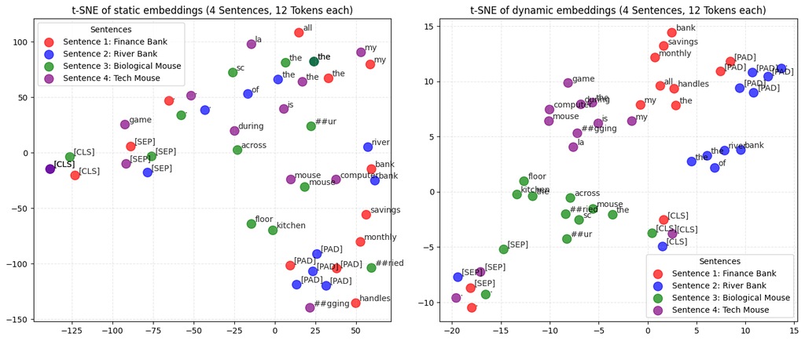

```python
fig, (ax1, ax2) = plt.subplots(1, 2, figsize=(14, 6))

plot_embedding(static_embeddings, ax1, embedding_type="static", tsne=True)
plot_embedding(dynamic_embeddings, ax2, embedding_type="dynamic", tsne=True)
plt.tight_layout()
plt.show()
```

## Exercise 2 Semantic Search and Retrieval Using Embeddings

In this final exercise, you will build a semantic search system using multiple embedding types and evaluate retrieval quality. This demonstrates how embeddings enable downstream tasks beyond classification.

**Task Description:** You will implement semantic search using:

- Word2Vec (static embeddings)
- BERT mean-pooled (mean of sentence/document) contextual embeddings
- Sentence-BERT (SBERT) sentence embeddings

**Steps:**

1. Load or create a small text corpus (FAQ-like statements)
2. Generate embeddings using all three methods
3. Implement cosine-similarity-based retrieval
4. Rank documents for a user query
5. Evaluate with:
   - Precision@k
   - Recall@k
   - Mean Reciprocal Rank (MRR)
6. Visualize embeddings using t-SNE

**Deliverables:**

- Notebook containing all embedding methods
- Retrieval system implementation
- Evaluation metrics and t-SNE visualization
- Discussion of results for the presentation: What are the limits of this approach?

**Answer**

The limits are that the words used in the query need to be present in the corpus themselves (or at least synonyms). The headings themselves (or at least parts of the text) need to match the words of the query, meaning it is a bit of a fancier word search system rather than something that can actuall formulate answers. It does not understand the question, as such asking for how to make an omlette could give you the recepie of a different dish simply because the different dish is compared to an omlette in the recepie and the omlette recepie is ignored because omlette is only mentioned in the heading.

From the results SBERT seems to dominat, acutally getting all my queries correct (though they are rather carefully formulated), while w2v is the weekest one (expected).

### Get FAQ from wikihow

Reading in data and making the corpus usable

```python
import requests
from bs4 import BeautifulSoup
from pathlib import Path
from nltk.tokenize import sent_tokenize
```

```python
if (faq_file := Path("./faq.html")).exists():
    with open(faq_file, "rb") as f:
        print("Reading from txt to save on data ψ(｀∇´)ψ")
        soup = BeautifulSoup(f.read())
else:
    print("Querying the wiki ... (T_T)")
    response = requests.get("https://www.wikihow.com/Calculate-Pi-by-Throwing-Frozen-Hot-Dogs")
    soup = BeautifulSoup(response.content)
    with open("./faq.html", "w", encoding="utf-8") as f:
        f.write(response.text)
```

```
Reading from txt to save on data ψ(｀∇´)ψ
```

```python
# legacy
# text = soup.select_one("h1").text
# for div in soup.select("div.steps"):
#     if (t:= div.text) != "\n":
#         text+=div.text.strip().replace("\n\n\n", "")
# print(text[:50])
```

```python
text = [soup.select_one("h1").text]
for step in soup.select("ol.steps_list_2 li div.step"):
    for sup in step.select("sup"):
        sup.decompose()

    # Now print the cleaned text
    text.append(step.get_text(strip=True))
    print(step.get_text(strip=True))
```

```
Select a food item to throw.There are a couple of qualifications. First, it must be long, thin, hard, and straight, like a frozen hot dog, for example. Second, it must be a reasonably stiff item. Third, it should be somewhere between 15 and 20 cm (6-8 inches) long; the experiment can be performed ot…
Select the spot from which to throw your mathematical cuisine.You will probably need about 180-300 cm (6-10 feet) in front of you, as you will be throwing straight ahead.
Clear the area.The place at which you are throwing should be devoid of objects that your food item could possibly run in to. So, if you are throwing in your kitchen, consider moving the table into another room or at least throwing in such a way that your food won't hit the table during its flight.
Measure the length of your projectile.A tape measure should do the trick. Be as accurate as you can, even down to the millimeter, for best results. Since length is a factor, it’s best to choose food items that are all the same size. If you’ve chosen something that isn’t naturally uniform, such as ce…
Lay down masking tape in parallel strips across the floor as far apart as your projectile is long.The strips should be perpendicular to the direction you will be throwing. If your item is 15-45 cm (6-18 inches) long, lay down about 6-10 strips; lay down fewer if longer and more if shorter.
On a piece of paper, make a column for “Tosses” and another column for "Crosses."The "Tosses" column is where you’ll keep track of how many times you throw your food item. The "Crosses" column is where you’ll keep track of how many times your item lands across one of the lines. (Note that landing is…
Get into position and THROW YOUR FOOD!Throw just one item at a time. Once it is at rest, observe whether or not it is crossing one of the lines. If it is, put a tick under "Crosses" and a tick under "Tosses." If it isn't, just put a tick under "Tosses." When you’ve run out of hot dogs, pick them up …
When you’re done, divide the number of crosses by 2 and divide the number of tosses by that.For example, if you threw 300 times, and it crossed 191 times, you would calculate 300/(191/2). And, to your amazement, you will now have an approximation for pi!
```

```python
# corpus: list[str] = sent_tokenize(text)
corpus = text
corpus
```

```
['How to Compute Pi with Frozen Hot Dog Wieners',
 "Select a food item to throw.There are a couple of qualifications. First, it must be long, thin, hard, and straight, like a frozen hot dog, for example. Second, it must be a reasonably stiff item. Third, it should be somewhere between 15 and 20 cm (6-8 inches) long; the experiment can be performed …
 'Select the spot from which to throw your mathematical cuisine.You will probably need about 180-300 cm (6-10 feet) in front of you, as you will be throwing straight ahead.',
 "Clear the area.The place at which you are throwing should be devoid of objects that your food item could possibly run in to. So, if you are throwing in your kitchen, consider moving the table into another room or at least throwing in such a way that your food won't hit the table during its flight.…
 'Measure the length of your projectile.A tape measure should do the trick. Be as accurate as you can, even down to the millimeter, for best results. Since length is a factor, it’s best to choose food items that are all the same size. If you’ve chosen something that isn’t naturally uniform, such as …
 'Lay down masking tape in parallel strips across the floor as far apart as your projectile is long.The strips should be perpendicular to the direction you will be throwing. If your item is 15-45 cm (6-18 inches) long, lay down about 6-10 strips; lay down fewer if longer and more if shorter.',
 'On a piece of paper, make a column for “Tosses” and another column for "Crosses."The "Tosses" column is where you’ll keep track of how many times you throw your food item. The "Crosses" column is where you’ll keep track of how many times your item lands across one of the lines. (Note that landing …
 'Get into position and THROW YOUR FOOD!Throw just one item at a time. Once it is at rest, observe whether or not it is crossing one of the lines. If it is, put a tick under "Crosses" and a tick under "Tosses." If it isn\'t, just put a tick under "Tosses." When you’ve run out of hot dogs, pick them …
 'When you’re done, divide the number of crosses by 2 and divide the number of tosses by that.For example, if you threw 300 times, and it crossed 191 times, you would calculate 300/(191/2). And, to your amazement, you will now have an approximation for pi!']
```

### Process the Corpus

i.e. match it with my query

```python
from gensim.models import Word2Vec
from nltk.tokenize import word_tokenize
from sentence_transformers import SentenceTransformer
import torch.nn.functional as F
```

```python
query = "What are the important qualifications for the food item I want to throw?"
```

```python
def show_most_similar_instruction(query_vec, corpus_vecs, name):
    # cosine similarity from torch
    scores = F.cosine_similarity(query_vec, corpus_vecs)
    best_idx = torch.argmax(scores).item()
    text = f"{name:<6} Best Match: '{corpus[best_idx]}'"
    return text, scores[best_idx], best_idx
```

```python
corpus[:5]
```

```
['How to Compute Pi with Frozen Hot Dog Wieners',
 "Select a food item to throw.There are a couple of qualifications. First, it must be long, thin, hard, and straight, like a frozen hot dog, for example. Second, it must be a reasonably stiff item. Third, it should be somewhere between 15 and 20 cm (6-8 inches) long; the experiment can be performed …
 'Select the spot from which to throw your mathematical cuisine.You will probably need about 180-300 cm (6-10 feet) in front of you, as you will be throwing straight ahead.',
 "Clear the area.The place at which you are throwing should be devoid of objects that your food item could possibly run in to. So, if you are throwing in your kitchen, consider moving the table into another room or at least throwing in such a way that your food won't hit the table during its flight.…
 'Measure the length of your projectile.A tape measure should do the trick. Be as accurate as you can, even down to the millimeter, for best results. Since length is a factor, it’s best to choose food items that are all the same size. If you’ve chosen something that isn’t naturally uniform, such as …
```

#### w2v

```python
w2v_size = 100

tokenized_corpus = [word_tokenize(x) for x in corpus]
w2v_model = Word2Vec(sentences=tokenized_corpus, vector_size=w2v_size, window=5, min_count=2)

def get_w2v_avg(tokens):
    vecs = [w2v_model.wv[word] for word in tokens if word in w2v_model.wv]
    return np.mean(vecs, axis=0) if vecs else np.zeros(w2v_size)

print(tokenized_corpus)
```

```
[['How', 'to', 'Compute', 'Pi', 'with', 'Frozen', 'Hot', 'Dog', 'Wieners'], ['Select', 'a', 'food', 'item', 'to', 'throw.There', 'are', 'a', 'couple', 'of', 'qualifications', '.', 'First', ',', 'it', 'must', 'be', 'long', ',', 'thin', ',', 'hard', ',', 'and', 'straight', ',', 'like', 'a', 'frozen', …
```

```python
corpus_w2v = torch.tensor([get_w2v_avg(tokens) for tokens in tokenized_corpus])
query_w2v = torch.tensor(get_w2v_avg(word_tokenize(query))).unsqueeze(0)# adds extra dimension of size 1 to match it up with the other 2d
print("corpus tensor: ", corpus_w2v.size(),"query tensor", query_w2v.size())
text, score,_ = show_most_similar_instruction( query_w2v,corpus_w2v, "Word2Vec")
print(text, f"Score: {score:.4f}")
```

```
corpus tensor:  torch.Size([9, 100]) query tensor torch.Size([1, 100])
Word2Vec Best Match: 'Measure the length of your projectile.A tape measure should do the trick. Be as accurate as you can, even down to the millimeter, for best results. Since length is a factor, it’s best to choose food items that are all the same size. If you’ve chosen something that isn’t natural…
```

#### Mean-pooled Bert

```python
tokenizer: BertTokenizer = BertTokenizer.from_pretrained("bert-base-uncased")
model = BertModel.from_pretrained("bert-base-uncased")
```

[output not shown]

```python
def mean_pool_bert(corpus: list[str]) -> torch.Tensor:
    outputs=[]
    for sentence in corpus:
        input = tokenizer(sentence, return_tensors="pt")
        with torch.no_grad():
            out = model(**input)
            out = out.last_hidden_state
        out = torch.mean(out, 1).squeeze(0)
        outputs.append(out)
    return torch.stack(outputs, 0)
```

```python
corpus_bert = mean_pool_bert(corpus)
query_bert = mean_pool_bert([query])
print("corpus tensor: ", corpus_bert.size(),"query tensor", query_bert.size())
text, score,_ = show_most_similar_instruction( query_bert,corpus_bert, "Bert")
print(text, f"Score: {score:.4f}")
```

```
corpus tensor:  torch.Size([9, 768]) query tensor torch.Size([1, 768])
Bert   Best Match: 'Select a food item to throw.There are a couple of qualifications. First, it must be long, thin, hard, and straight, like a frozen hot dog, for example. Second, it must be a reasonably stiff item. Third, it should be somewhere between 15 and 20 cm (6-8 inches) long; the experiment…
```

#### SBert

```python
smodel =  SentenceTransformer(model_name_or_path="all-MiniLM-L6-v2")
```

```
BertModel LOAD REPORT from: sentence-transformers/all-MiniLM-L6-v2
Key                     | Status     |  |
------------------------+------------+--+-
embeddings.position_ids | UNEXPECTED |  |

Notes:
- UNEXPECTED	:can be ignored when loading from different task/architecture; not ok if you expect identical arch.
```

```python
corpus_sbert = smodel.encode(corpus, convert_to_tensor=True)
query_sbert = smodel.encode([query], convert_to_tensor=True)
print("corpus tensor: ", corpus_sbert.size(),"query tensor", query_sbert.size())
text, score,_ = show_most_similar_instruction(query_sbert, corpus_sbert, "SBERT")
print(text, f"Score: {score:.4f}")
```

```
corpus tensor:  torch.Size([9, 384]) query tensor torch.Size([1, 384])
SBERT  Best Match: 'Select a food item to throw.There are a couple of qualifications. First, it must be long, thin, hard, and straight, like a frozen hot dog, for example. Second, it must be a reasonably stiff item. Third, it should be somewhere between 15 and 20 cm (6-8 inches) long; the experiment…
```

#### Ranking

```python
results = []
results.append(show_most_similar_instruction(query_w2v, corpus_w2v, "W2V"))
results.append(show_most_similar_instruction(query_bert, corpus_bert, "BERT"))
results.append(show_most_similar_instruction(query_sbert, corpus_sbert, "SBERT"))
results.sort(key=lambda x: x[1], reverse=True)
for place, (text, score, _) in enumerate(results, 1):
    print(f"{place}. {text[:97]+'...' if len(text)>100 else text:<100}", f"\t(Cosine similarty Score: {score:.4f})")
```

```
1. SBERT  Best Match: 'Select a food item to throw.There are a couple of qualifications. First, it m... 	(Cosine similarty Score: 0.7498)
2. BERT   Best Match: 'Select a food item to throw.There are a couple of qualifications. First, it m... 	(Cosine similarty Score: 0.7138)
3. W2V    Best Match: 'Measure the length of your projectile.A tape measure should do the trick. Be ... 	(Cosine similarty Score: 0.4551)
```

### Evaluation

of the results of the differing embedding systems

```python
corpus
```

```
['How to Compute Pi with Frozen Hot Dog Wieners',
 "Select a food item to throw.There are a couple of qualifications. First, it must be long, thin, hard, and straight, like a frozen hot dog, for example. Second, it must be a reasonably stiff item. Third, it should be somewhere between 15 and 20 cm (6-8 inches) long; the experiment can be performed …
 'Select the spot from which to throw your mathematical cuisine.You will probably need about 180-300 cm (6-10 feet) in front of you, as you will be throwing straight ahead.',
 "Clear the area.The place at which you are throwing should be devoid of objects that your food item could possibly run in to. So, if you are throwing in your kitchen, consider moving the table into another room or at least throwing in such a way that your food won't hit the table during its flight.…
 'Measure the length of your projectile.A tape measure should do the trick. Be as accurate as you can, even down to the millimeter, for best results. Since length is a factor, it’s best to choose food items that are all the same size. If you’ve chosen something that isn’t naturally uniform, such as …
 'Lay down masking tape in parallel strips across the floor as far apart as your projectile is long.The strips should be perpendicular to the direction you will be throwing. If your item is 15-45 cm (6-18 inches) long, lay down about 6-10 strips; lay down fewer if longer and more if shorter.',
 'On a piece of paper, make a column for “Tosses” and another column for "Crosses."The "Tosses" column is where you’ll keep track of how many times you throw your food item. The "Crosses" column is where you’ll keep track of how many times your item lands across one of the lines. (Note that landing …
 'Get into position and THROW YOUR FOOD!Throw just one item at a time. Once it is at rest, observe whether or not it is crossing one of the lines. If it is, put a tick under "Crosses" and a tick under "Tosses." If it isn\'t, just put a tick under "Tosses." When you’ve run out of hot dogs, pick them …
 'When you’re done, divide the number of crosses by 2 and divide the number of tosses by that.For example, if you threw 300 times, and it crossed 191 times, you would calculate 300/(191/2). And, to your amazement, you will now have an approximation for pi!']
```

```python
queries = [
    "How to compute Pi?",
    "What are the important qualifications for the food item I want to throw?",
    "How much space do I need in front of me?",
    "What is important abou the throwing area?",
    "Which columns do I need on my piece of paper?"
]
ground_truth = [0, 1, 2, 3, 6]
```

```python
corpus_w2v = torch.tensor([get_w2v_avg(tokens) for tokens in tokenized_corpus])
query_w2v = torch.tensor([get_w2v_avg(word_tokenize(query)) for query in queries])
corpus_bert = mean_pool_bert(corpus)
query_bert = mean_pool_bert(queries)
corpus_sbert = smodel.encode(corpus, convert_to_tensor=True)
query_sbert = smodel.encode(queries, convert_to_tensor=True)
```

**AI assistet**

This function was partially writen by AI with me asking individual questions about what the metrics are and how they work, as well as how to get Tensor similarty, as it is multiple prompt whose answers were rewriten I will not list them all

```python
def evaluate_retrieval(query_embeddings: torch.Tensor, corpus_embeddings: torch.Tensor, ground_truth: list[int]):
    """evaluate retrievelvs
        query_embeddings: (num_queries, dim)
        corpus_embeddings: (num_corpus, dim)
        ground_truth: list of correct corpus indices for each query e.g., [2, 0, 5]
    """
    # 1. Compute all-to-all cosine similarity
    # torches cosine similarty function does not work :(, since the tensor are different sizes
    # so use the normal formula x/|x| * y/|y| deviding a vector by length is normalisation (remove length only direction), then we do the direction
    q_norm = F.normalize(query_embeddings, p=2, dim=1)
    c_norm = F.normalize(corpus_embeddings, p=2, dim=1)
    # matrix multiplication gives angle/cosine sim, remember orthoganl vectors have a dot product of 0
    sim_matrix = q_norm @ c_norm.transpose(0, 1) # (num_queries, num_corpus)

    # 2. Get top-k indices
    k = 3
    top_k_indices: list[list[int]] = torch.topk(sim_matrix, k=k, dim=1).indices.tolist()# top 3 for every query

    mrr = 0
    precision_at_k = 0
    recall_at_k = 0

    for i, correct_idx in enumerate(ground_truth):
        retrieved = top_k_indices[i]

        # Precision@k = accuracy
        # HOW MANY of the suggested items are correct, at most 1/3rd per query as only 1 answer matches my queries :3
        if correct_idx in retrieved:
            precision_at_k += (1 / k)

        # Recall@k
        # ANY of the suggesions correct
        if correct_idx in retrieved:
            recall_at_k += 1

        # --- MRR ---
        # How is the correct answer ranked? Higher rank of correct answers = higher score
        if correct_idx in retrieved:
            rank = retrieved.index(correct_idx) + 1
            mrr += (1 / rank)

    precision_at_k /= len(ground_truth) # make it percentage based
    recall_at_k/=len(ground_truth) # same as precision
    mrr /=len(ground_truth) # same as mrr
    print(top_k_indices)
    print(f"P@{k}: {precision_at_k*100:.2f}%")
    print(f"R@{k}: {recall_at_k*100:.2f}%")
    print(f"MRR: {mrr}")
```

```python
print("Word2Vec:")
evaluate_retrieval(query_w2v, corpus_w2v, ground_truth)
print(f"{'-'*50}\n")
print("Bert")
evaluate_retrieval(query_bert, corpus_bert, ground_truth)
print(f"{'-'*50}\n")
print("SBert")
evaluate_retrieval(query_sbert, corpus_sbert, ground_truth)
```

```
Word2Vec:
[[0, 2, 4], [4, 3, 8], [2, 3, 6], [3, 5, 4], [6, 2, 8]]
P@3: 26.67%
R@3: 80.00%
MRR: 0.8
--------------------------------------------------

Bert
[[0, 8, 4], [1, 3, 4], [2, 0, 4], [2, 3, 7], [0, 6, 1]]
P@3: 33.33%
R@3: 100.00%
MRR: 0.8
--------------------------------------------------

SBert
[[0, 8, 2], [1, 3, 2], [2, 5, 3], [3, 2, 1], [6, 2, 4]]
P@3: 33.33%
R@3: 100.00%
MRR: 1.0
```

**AI usage**

Prompt: "At the end of Exercise 2 before Exercise 3 starts build a visualisation of the embeddings from exercise 2 using tsne" Model: Copielet agent

### t-SNE Visualization of Embeddings

Visualize the embedding spaces from all three methods (Word2Vec, BERT, and SBERT) to compare how each method represents the corpus documents and query in 2D space.

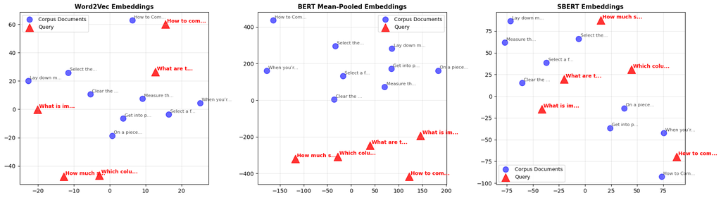

```python
# Prepare data for t-SNE visualization
def visualize_embeddings_tsne_subplot(corpus_embeddings, query_embeddings, corpus_texts, query_text, ax, title):
    """
    Visualize corpus and query embeddings using t-SNE on a given axis
    """
    # Combine corpus and query embeddings
    all_embeddings = torch.cat([corpus_embeddings, query_embeddings], dim=0)

    all_embeddings = all_embeddings.cpu().numpy()

    # Apply t-SNE
    tsne = TSNE(n_components=2, perplexity=5, random_state=42, init='pca', learning_rate='auto', metric='cosine')
    reduced_embeddings = tsne.fit_transform(all_embeddings)

    # Plot corpus documents
    ax.scatter(reduced_embeddings[:-len(query_embeddings), 0],
               reduced_embeddings[:-len(query_embeddings), 1],
               c='blue', s=100, alpha=0.6, label='Corpus Documents')

    # Plot query
    ax.scatter(reduced_embeddings[-len(query_embeddings):, 0],
               reduced_embeddings[-len(query_embeddings):, 1],
               c='red', s=200, alpha=0.8, marker='^', label='Query')

    # Annotate corpus documents with first 10 characters
    for i, text in enumerate(corpus_texts):
        label = (text[:10] + "...") if len(text) > 10 else text
        ax.annotate(label,
                   (reduced_embeddings[i, 0], reduced_embeddings[i, 1]),
                   fontsize=8, alpha=0.7, xytext=(3, 3), textcoords='offset points')

    # Annotate query with first 10 characters
    for i, text in enumerate(query_text):
        query_label = (text[:10] + "...") if len(text) > 10 else text
        ax.annotate(query_label,
                (reduced_embeddings[len(corpus_embeddings)+i, 0], reduced_embeddings[len(corpus_embeddings)+i, 1]),
                fontsize=9, fontweight='bold', color='red', xytext=(3, 3), textcoords='offset points')

    ax.set_title(f"{title}", fontsize=11, fontweight='bold')
    ax.legend(fontsize=9)
    ax.grid(True, alpha=0.3)

# Create subplots for all three methods
fig, axes = plt.subplots(1, 3, figsize=(18, 5))

visualize_embeddings_tsne_subplot(corpus_w2v, query_w2v, corpus, queries, axes[0], "Word2Vec Embeddings")
visualize_embeddings_tsne_subplot(corpus_bert, query_bert, corpus, queries, axes[1], "BERT Mean-Pooled Embeddings")
visualize_embeddings_tsne_subplot(corpus_sbert, query_sbert, corpus, queries, axes[2], "SBERT Embeddings")

plt.tight_layout()
plt.show()
```

## Exercise 3 Text Classification with various Embeddings

In this exercise, you will classify SMS messages as spam or ham using multiple embedding methods.

**Embedding Methods:**

- BERT [CLS] token embedding
- BERT mean-pooled token embeddings
- Word2Vec trained on the dataset

You will train a classifier of your choice on each embedding type and compare performance using classification reports, confusion matrices, and qualitative error analysis. Additionally research online when to use the [CLS] token and when to use mean-pooling.

- train classifier on each embedding
- compare performance
  - classification reports
  - confusion matrices
  - qualitative error analysis
- research when to use CLS and mean-pooling

**Deliverables:**

- Embedding extraction code
- Classifier training and evaluation
- A comparison of all methods to present in the exercise.
- Analysis on [CLS] token vs mean-pooling.

**Answers**

The CLS token is made to take on the meaning of the entire sentece durring the transformers runthroughs so it can be used for generative modeling, i.e. used by the model to predict the next sentence.

With mean-pooling we average all tokens over the entire sentece, as such it loses less context for very long texts, so it is ususally used for semantic similarty or clustering.

With my network the difference between CLS and MP was 1 sample that CLS got more wrong, as such they could be considered equal for this classification task.

For my final classifer the mean-pooled Bert using the MyNN the errors seem to stem from slang and using shorthands of words, as well numbers.

```python
from sklearn.model_selection import train_test_split
from sklearn.metrics import accuracy_score, precision_score, recall_score, f1_score, confusion_matrix, ConfusionMatrixDisplay

from collections import defaultdict

from numpy import ndarray

from torch import nn
from torch.utils.data import TensorDataset, DataLoader
```

```python
df = pd.read_csv("train.csv")
X, y = df["sms"].to_numpy(), df["label"].to_numpy()
X_train, X_val, y_train, y_val = train_test_split(X, y, test_size=0.3, stratify=y, random_state=42)
X_val, X_test, y_val, y_test = train_test_split(X_val, y_val, test_size=0.5, stratify=y_val, random_state=42)
X_train[:5], y_train[:5]
```

```
(array(["Its on in engalnd! But telly has decided it won't let me watch it and mia and elliot were kissing! Damn it!\n",
        'No, but you told me you were going, before you got drunk!\n',
        'Not yet chikku..wat abt u?\n',
        'Moji i love you more than words. Have a rich day\n',
        'Ok. How many should i buy.\n'], dtype=object),
 array([0, 0, 0, 0, 0]))
```

```python
# check if really stratified
for split_x, split_y in [(X_train, y_train),(X_val, y_val), (X_test, y_test)]:
    print("{:.2f}%".format( sum(split_y == 1)/sum(split_y==0) * 100))
```

```
15.48%
15.47%
15.45%
```

```python
EPOCHS = 10
device = torch.accelerator.current_accelerator().type if torch.accelerator.is_available() else "cpu"
device = "cpu" # just faster for this tinsy tiny model
device
```

```
'cpu'
```

```python
# Model
# Choose a torch Fully connected NN
loss_fn = nn.BCEWithLogitsLoss()

class MyNN(nn.Module):
    def __init__(self, input_size) -> None:
        super().__init__()
        self.linear_relu_stack = nn.Sequential(
            nn.Linear(input_size, 16),
            nn.ReLU(),
            nn.Linear(16, 16),
            nn.ReLU(),
            nn.Linear(16, 1)
        )

    def forward(self, x):
        return self.linear_relu_stack(x).squeeze(-1)

def train(dataloader: DataLoader, model:MyNN, optimizer: torch.optim.SparseAdam):
    size = len(dataloader.dataset)#type:ignore
    model.train()
    for batch, (X, y) in enumerate(dataloader):
        X, y = X.to(device), y.to(device)

        # Compute prediction error
        pred = model(X)
        loss = loss_fn(pred, y)

        # Backpropagation
        loss.backward()
        optimizer.step()
        optimizer.zero_grad()

        if batch % 20 == 0:
            loss, current = loss.item(), (batch + 1) * len(X)
            print(f"loss: {loss:>7f}  [{current:>5d}/{size:>5d}]")

def test(dataloader: DataLoader, model: MyNN, split: str):
    size = len(dataloader.dataset)#type:ignore
    num_batches = len(dataloader)
    model.eval()
    test_loss, correct = 0, 0
    with torch.no_grad():
        for X, y in dataloader:
            X, y = X.to(device), y.to(device)
            pred = model(X)
            test_loss += loss_fn(pred, y).item()
            correct += ((pred>0).float() == y).type(torch.float).sum().item()
    test_loss /= num_batches
    correct /= size
    print(f"{split} Error: \n Accuracy: {(100*correct):>0.1f}%, Avg loss: {test_loss:>8f} \n")

def make_dataloader(X: torch.Tensor, y: ndarray, shuffle = True)-> DataLoader:
    dataset = TensorDataset(X.type(torch.float), torch.from_numpy(y.astype(np.float32)))
    dataloader = DataLoader(dataset, batch_size=64, shuffle=shuffle)
    return dataloader
```

### w2v

```python
w2v_size = 100

tokenized_corpus_train = [word_tokenize(x) for x in X_train]
tokenized_corpus_val = [word_tokenize(x) for x in X_val]
w2v_model = Word2Vec(sentences=tokenized_corpus_train, vector_size=w2v_size, window=5, min_count=2)

def get_w2v_avg(tokens):
    vecs = [w2v_model.wv[word] for word in tokens if word in w2v_model.wv]
    return np.mean(vecs, axis=0) if vecs else np.zeros(w2v_size)

corpus_w2v_train = torch.tensor([get_w2v_avg(tokens) for tokens in tokenized_corpus_train])
corpus_w2v_val = torch.tensor([get_w2v_avg(tokens) for tokens in tokenized_corpus_val])
dl_w2v_train = make_dataloader(corpus_w2v_train, y_train)
dl_w2v_val = make_dataloader(corpus_w2v_val, y_val)
corpus_w2v_train.size()
```

```
torch.Size([3901, 100])
```

```python
w2v_classifier = MyNN(corpus_w2v_train.size()[1]).to(device)
optimizer = torch.optim.Adam(w2v_classifier.parameters(), lr=1e-3)
for t in range(EPOCHS):
    print(f"Epoch {t+1}\n-------------------------------")
    train(dl_w2v_train, w2v_classifier,  optimizer)
    test(dl_w2v_val, w2v_classifier, "val")
print("Done!")
```

```
Epoch 1
-------------------------------
loss: 0.777501  [   64/ 3901]
loss: 0.689170  [ 1344/ 3901]
loss: 0.568461  [ 2624/ 3901]
loss: 0.384588  [ 3721/ 3901]
val Error:
 Accuracy: 86.5%, Avg loss: 0.396476

Epoch 2
-------------------------------
loss: 0.441334  [   64/ 3901]
loss: 0.325255  [ 1344/ 3901]
loss: 0.384938  [ 2624/ 3901]
loss: 0.372696  [ 3721/ 3901]
val Error:
 Accuracy: 86.6%, Avg loss: 0.387189

Epoch 3
-------------------------------
loss: 0.557460  [   64/ 3901]
loss: 0.268153  [ 1344/ 3901]
loss: 0.281948  [ 2624/ 3901]
loss: 0.294813  [ 3721/ 3901]
val Error:
 Accuracy: 86.6%, Avg loss: 0.357369

Epoch 4
-------------------------------
loss: 0.432152  [   64/ 3901]
loss: 0.461315  [ 1344/ 3901]
loss: 0.446879  [ 2624/ 3901]
loss: 0.250982  [ 3721/ 3901]
val Error:
 Accuracy: 86.6%, Avg loss: 0.384969

Epoch 5
-------------------------------
loss: 0.428397  [   64/ 3901]
loss: 0.415785  [ 1344/ 3901]
```

[output cut: 36 more lines]

```
loss: 0.270017  [ 2624/ 3901]
loss: 0.429266  [ 3721/ 3901]
val Error:
 Accuracy: 86.6%, Avg loss: 0.371621

Epoch 10
-------------------------------
loss: 0.376916  [   64/ 3901]
loss: 0.402231  [ 1344/ 3901]
loss: 0.239609  [ 2624/ 3901]
loss: 0.269881  [ 3721/ 3901]
val Error:
 Accuracy: 86.6%, Avg loss: 0.366499

Done!
```

### Bert Meanpooled

```python
tokenizer: BertTokenizer = BertTokenizer.from_pretrained("bert-base-uncased")
model = BertModel.from_pretrained("bert-base-uncased")
def mean_pool_bert(corpus: list[str]) -> torch.Tensor:
    outputs=[]
    for sentence in corpus:
        input = tokenizer(sentence, return_tensors="pt")
        with torch.no_grad():
            out = model(**input)
            out = out.last_hidden_state
        out = torch.mean(out, 1).squeeze(0)
        outputs.append(out)
    return torch.stack(outputs, 0)

corpus_bert_train = mean_pool_bert(X_train)
corpus_bert_val = mean_pool_bert(X_val)
dl_bert_train = make_dataloader(corpus_bert_train, y_train)
dl_bert_val = make_dataloader(corpus_bert_val, y_val)
corpus_bert_train.size()
```

[output not shown]

```
torch.Size([3901, 768])
```

```python
# device = torch.accelerator.current_accelerator().type
mean_pooled_classifier = MyNN(corpus_bert_train.size()[1]).to(device)
optimizer = torch.optim.Adam(mean_pooled_classifier.parameters(), lr=1e-3)
for t in range(EPOCHS):
    print(f"Epoch {t+1}\n-------------------------------")
    train(dl_bert_train, mean_pooled_classifier,  optimizer)
    test(dl_bert_val, mean_pooled_classifier, "val")
print("Done!")
```

```
Epoch 1
-------------------------------
loss: 0.610179  [   64/ 3901]
loss: 0.367566  [ 1344/ 3901]
loss: 0.322653  [ 2624/ 3901]
loss: 0.164165  [ 3721/ 3901]
val Error:
 Accuracy: 94.1%, Avg loss: 0.164324

Epoch 2
-------------------------------
loss: 0.239086  [   64/ 3901]
loss: 0.109434  [ 1344/ 3901]
loss: 0.077697  [ 2624/ 3901]
loss: 0.101292  [ 3721/ 3901]
val Error:
 Accuracy: 98.4%, Avg loss: 0.049652

Epoch 3
-------------------------------
loss: 0.078750  [   64/ 3901]
loss: 0.018672  [ 1344/ 3901]
loss: 0.101123  [ 2624/ 3901]
loss: 0.011250  [ 3721/ 3901]
val Error:
 Accuracy: 98.8%, Avg loss: 0.037120

Epoch 4
-------------------------------
loss: 0.023103  [   64/ 3901]
loss: 0.029924  [ 1344/ 3901]
loss: 0.201043  [ 2624/ 3901]
loss: 0.052918  [ 3721/ 3901]
val Error:
 Accuracy: 98.9%, Avg loss: 0.032204

Epoch 5
-------------------------------
loss: 0.027078  [   64/ 3901]
loss: 0.052333  [ 1344/ 3901]
```

[output cut: 36 more lines]

```
loss: 0.004850  [ 2624/ 3901]
loss: 0.013053  [ 3721/ 3901]
val Error:
 Accuracy: 98.7%, Avg loss: 0.035174

Epoch 10
-------------------------------
loss: 0.021557  [   64/ 3901]
loss: 0.002753  [ 1344/ 3901]
loss: 0.018852  [ 2624/ 3901]
loss: 0.004676  [ 3721/ 3901]
val Error:
 Accuracy: 98.8%, Avg loss: 0.029047

Done!
```

### CLS

```python
def get_cls_embbedings(corpus: list[str]):
    # input = tokenizer(list(corpus), return_tensors="pt", padding=True, truncation=True)
    # with torch.no_grad():
    #     out = model(**input)
    #     out = out.last_hidden_state
    outputs=[]
    for sentence in corpus:
        input = tokenizer(sentence, return_tensors="pt")
        with torch.no_grad():
            out = model(**input)
            out = out.last_hidden_state
        outputs.append(out[:, 0, :])
    return torch.stack(outputs, 0)

corpus_cls_bert_train = get_cls_embbedings(X_train).squeeze(1)
corpus_cls_bert_val = get_cls_embbedings(X_val).squeeze(1)
dl_cls_bert_train = make_dataloader(corpus_cls_bert_train, y_train)
dl_cls_bert_val = make_dataloader(corpus_cls_bert_val, y_val)
corpus_cls_bert_train.size()
```

```
torch.Size([3901, 768])
```

```python
# device = torch.accelerator.current_accelerator().type
cls_classifier = MyNN(corpus_cls_bert_train.size()[1]).to(device)
optimizer = torch.optim.Adam(cls_classifier.parameters(), lr=1e-3)
for t in range(EPOCHS):
    print(f"Epoch {t+1}\n-------------------------------")
    train(dl_cls_bert_train, cls_classifier,  optimizer)
    test(dl_cls_bert_val, cls_classifier, "val")
print("Done!")
```

```
Epoch 1
-------------------------------
loss: 0.680998  [   64/ 3901]
loss: 0.420635  [ 1344/ 3901]
loss: 0.337145  [ 2624/ 3901]
loss: 0.410294  [ 3721/ 3901]
val Error:
 Accuracy: 86.6%, Avg loss: 0.303393

Epoch 2
-------------------------------
loss: 0.392012  [   64/ 3901]
loss: 0.190249  [ 1344/ 3901]
loss: 0.204658  [ 2624/ 3901]
loss: 0.186003  [ 3721/ 3901]
val Error:
 Accuracy: 86.6%, Avg loss: 0.194527

Epoch 3
-------------------------------
loss: 0.118225  [   64/ 3901]
loss: 0.136840  [ 1344/ 3901]
loss: 0.157119  [ 2624/ 3901]
loss: 0.112597  [ 3721/ 3901]
val Error:
 Accuracy: 97.8%, Avg loss: 0.117744

Epoch 4
-------------------------------
loss: 0.089009  [   64/ 3901]
loss: 0.163389  [ 1344/ 3901]
loss: 0.054184  [ 2624/ 3901]
loss: 0.068944  [ 3721/ 3901]
val Error:
 Accuracy: 98.0%, Avg loss: 0.101723

Epoch 5
-------------------------------
loss: 0.089970  [   64/ 3901]
loss: 0.099458  [ 1344/ 3901]
```

[output cut: 36 more lines]

```
loss: 0.003977  [ 2624/ 3901]
loss: 0.019084  [ 3721/ 3901]
val Error:
 Accuracy: 98.8%, Avg loss: 0.026722

Epoch 10
-------------------------------
loss: 0.012385  [   64/ 3901]
loss: 0.006957  [ 1344/ 3901]
loss: 0.018029  [ 2624/ 3901]
loss: 0.101757  [ 3721/ 3901]
val Error:
 Accuracy: 98.7%, Avg loss: 0.027493

Done!
```

### Evaluation

```python
dl_w2v_val = make_dataloader(corpus_w2v_val, y_val, False) # need to redoo others shuffle, messes up metric latter
dl_bert_val = make_dataloader(corpus_bert_val, y_val, False)
dl_cls_bert_val = make_dataloader(corpus_cls_bert_val, y_val, False)

classifiers = [w2v_classifier, mean_pooled_classifier, cls_classifier]
val_sets = [dl_w2v_val, dl_bert_val, dl_cls_bert_val]
names = ["W2V", "MP", "CLS"]
results = defaultdict(list)

for model, dataloader, name in zip(classifiers, val_sets, names):
    size = len(dataloader.dataset)#type:ignore
    num_batches = len(dataloader)
    model.eval()
    test_loss, correct = 0, 0
    with torch.no_grad():
        for X, y in dataloader:
            X, y = X.to(device), y.to(device)
            pred = model(X)
            test_loss += loss_fn(pred, y).item()
            correct += ((pred>0).float() == y).type(torch.float).sum().item()
            results[name].append(pred)
    test_loss /= num_batches
    correct /= size
    print(f"Val Error: \n Accuracy: {(100*correct):>0.1f}%, Avg loss: {test_loss:>8f} \n")

results = {k:torch.cat(v, 0).apply_(lambda x: x >0).type(torch.int).numpy() for k, v in results.items()}
```

```
Val Error:
 Accuracy: 86.6%, Avg loss: 0.332866

Val Error:
 Accuracy: 98.8%, Avg loss: 0.028889

Val Error:
 Accuracy: 98.7%, Avg loss: 0.026874
```

```python
for k, v in results.items():
    print(f"Classification report of {k} (on val set):")
    print(f"\tAccuracy:  {accuracy_score(y_val, v)*100:.2f}%")
    print(f"\tPrecision:  {precision_score(y_val, v)*100:.2f}%")
    print(f"\tRecall:  {recall_score(y_val, v)*100:.2f}%")
    print(f"\tF1-Score:  {f1_score(y_val, v)*100:.2f}%")
    print()
```

```
Classification report of W2V (on val set):
	Accuracy:  86.60%
	Precision:  0.00%
	Recall:  0.00%
	F1-Score:  0.00%

Classification report of MP (on val set):
	Accuracy:  98.80%
	Precision:  96.36%
	Recall:  94.64%
	F1-Score:  95.50%

Classification report of CLS (on val set):
	Accuracy:  98.68%
	Precision:  94.69%
	Recall:  95.54%
	F1-Score:  95.11%
```

```python
corpus_bert_test = mean_pool_bert(corpus=X_test)
dl_bert_test = make_dataloader(corpus_bert_test, y_test, False)

preds = []
size = len(dl_bert_test.dataset)#type:ignore
num_batches = len(dl_bert_test)
mean_pooled_classifier.eval()
with torch.no_grad():
    for X, y in dl_bert_test:
        X, y = X.to(device), y.to(device)
        pred = mean_pooled_classifier(X)
        preds.append(pred)
pred_test = torch.cat(preds, 0).apply_(lambda x: x >0).type(torch.int).numpy()
print(f"Classification report of Mean-Pooled Bert (on Test set):")
print(f"\tAccuracy:  {accuracy_score(y_test, pred_test)*100:.2f}%")
print(f"\tPrecision:  {precision_score(y_test, pred_test)*100:.2f}%")
print(f"\tRecall:  {recall_score(y_test, pred_test)*100:.2f}%")
print(f"\tF1-Score:  {f1_score(y_test, pred_test)*100:.2f}%")
```

```
Classification report of Mean-Pooled Bert (on Test set):
	Accuracy:  99.16%
	Precision:  97.30%
	Recall:  96.43%
	F1-Score:  96.86%
```

**AI usage**

Prompt: "for sklearn confusion matrix how can i plot 3 of them next to eachother"

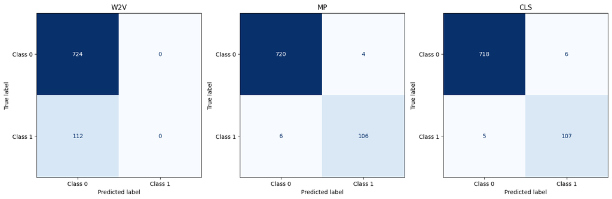

```python
# 1. Create a figure with 1 row and 3 columns
fig, axes = plt.subplots(1, 3, figsize=(15, 5))

for i, ax in enumerate(axes):
    # 2. Generate the matrix
    cm = confusion_matrix(y_val, results[names[i]])

    # 3. Display it on the specific axis
    disp = ConfusionMatrixDisplay(confusion_matrix=cm, display_labels=['Class 0', 'Class 1'])
    disp.plot(ax=ax, cmap='Blues', colorbar=False)

    ax.set_title(names[i])

plt.tight_layout()
plt.show()
```

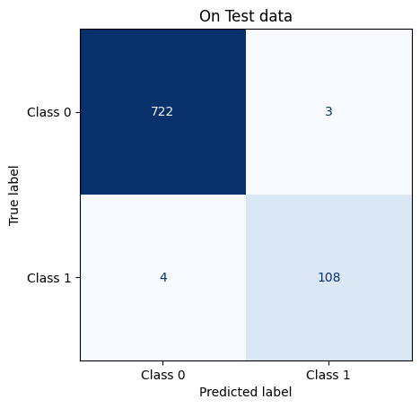

```python
cm = confusion_matrix(y_test, pred_test)
disp = ConfusionMatrixDisplay(confusion_matrix=cm, display_labels=['Class 0', 'Class 1'])
disp.plot(cmap='Blues', colorbar=False)
plt.title("On Test data")
plt.show()
```

```python
indx = np.where(pred_test != y_test)
for sentence, clasification in zip(X_test[indx], y_test[indx]):
    print(f"Was incorrectly classified as {'SPAM' if clasification == 0 else 'HAM'}")
    print(sentence)
```

```
Was incorrectly classified as SPAM
Funny fact Nobody teaches volcanoes 2 erupt, tsunamis 2 arise, hurricanes 2 sway aroundn no 1 teaches hw 2 choose a wife Natural disasters just happens

Was incorrectly classified as HAM
Xmas & New Years Eve tickets are now on sale from the club, during the day from 10am till 8pm, and on Thurs, Fri & Sat night this week. They're selling fast!

Was incorrectly classified as HAM
RCT' THNQ Adrian for U text. Rgds Vatian

Was incorrectly classified as HAM
Sexy Singles are waiting for you! Text your AGE followed by your GENDER as wither M or F E.G.23F. For gay men text your AGE followed by a G. e.g.23G.

Was incorrectly classified as SPAM
I take it the post has come then! You must have 1000s of texts now! Happy reading. My one from wiv hello caroline at the end is my favourite. Bless him

Was incorrectly classified as HAM
FreeMsg>FAV XMAS TONES!Reply REAL

Was incorrectly classified as SPAM
staff.science.nus.edu.sg/~phyhcmk/teaching/pc1323
```

## Exercise 4 Code Classification with BERT Embeddings

This exercise you will classify short code snippets using contextual embeddings. As calculating the embeddings is quite resource intensive you are provided the embeddings and the base notebook on eLearning. You will:

- Load and preprocess a labeled code dataset
- Generate BERT embeddings (already provided to you to save time)
- Train a traditional classifier (eg. LogisticRegression from sklearn)
- Evaluate with confusion matrix and classification report
- Prepare for the presentation in the exercise, what worked well / didn’t work well and why that might be the case.

**Deliverables:** Notebook with embedding extraction, model training, evaluation, and analysis of the findings.

**Answers**

There are big class imbalances, with some classes only havinig 1 instance within nearly 90 thousand rows of data, as such in the preprocessing I simply grouped all languages with less than 1 thousand entries as other.

In the confusion matrix we cann see that its mostly uniform colour other than the diagnoal and quite a heavy oerlap of classifying javascript+java as dart (class with most lables). Most likly because of very similar syntax, not to similar to the human eye on first look but they use quite a few similar words, like void, class, String....

It is also important to mention that it had difficulties identifying c, c++, php, sql and text (remember min 1000 per class), for these there is no clear overlap with otherclasses but simply a spread across all of them.

My tyny NN classifier seems to have done a bit better on truly strugglying with identifying C.

*Dart*

```
void greet(String name) {
  final message = "Hello, " + name;
  print(message);
}

void main() {
  greet("World");
}
```

*Java*

```
public class Greeter {
    public static void main(String[] args) {
        String name = "Java";
        sayHello(name);
    }

    public static void sayHello(String name) {
        System.out.println("Hello from " + name + "!");
    }
}
```

### Loading and preprocessing

```python
from sklearn.ensemble import RandomForestClassifier
```

```python
df = pd.read_feather("cleaned_data.feather")
df.drop(["id", "file_path", "file_size", "line_count", "extension"], axis=1, inplace=True)
df.head(5)
```

|  | language | content |
| --- | --- | --- |
| 0 | Markdown | \n\| Component \| Build Status ... |
| 1 | XML | <Project ToolsVersion="15.0" xmlns="http:\n ... |
| 2 | Text | The MIT License (MIT)\nCopyright (c) 2015 Micr... |
| 3 | Markdown | \n[![Packages](https:\nThis repository is for ... |
| 4 | Markdown | <!\nMicrosoft takes the security of our softwa... |

```python
len(pd.unique(df["language"]))
```

```
40
```

```python
threshold = 50
counts = df['language'].value_counts()

rare_languages = counts[counts < threshold].index

df['language'] = df['language'].mask(df['language'].isin(rare_languages), 'Other')
len(pd.unique(df["language"]))
```

```
40
```

```python
X, y = df["content"].to_numpy(), df["language"].to_numpy()
X_train, X_test, y_train, y_test = train_test_split(X, y, test_size=0.2, stratify=y, random_state=42)
X_train[:5], y_train[:5]
```

```
(array(['\npackage runtime\nimport (\n\t"internal/abi"\n\t"internal/cpu"\n\t"internal/goarch"\n\t"internal/goos"\n\t"runtime/internal/atomic"\n\t"runtime/internal/sys"\n\t"unsafe"\n)\nconst (\n\t_StackSystem = goos.IsWindows*512*goarch.PtrSize + goos.IsPlan9*512 + goos.IsIos*goarch.IsArm64*1024\n\t_…
        '\nnamespace Microsoft.Azure.Management.Network.Models\n{\n    public static class OutputType\n    {\n        public const string Workspace = "Workspace";\n    }\n}\n',
        'interface MyMap<K, V> {\n    operator fun get(k: K): V\n    operator fun set(k: K, v: V)\n}\nfun test(m: MyMap<String, Int>) {\n    ++<expr>m["a"]</expr>\n}',
        'defmodule ExUnit.Diff do\n  @moduledoc false\n  alias Inspect.Algebra\n  defstruct equivalent?: true,\n            left: nil,\n            right: nil\n  @doc """\n  Returns the diff between `left` and `right` and env after the comparison.\n  The `left` side can be a literal or an AST, the `…
        '@Deprecated("don\'t use i")\nval i: Int = 1\nfun test() {\n    <caret>i\n}\n'],
       dtype=object),
 array(['Go', 'C#', 'Kotlin', 'Elixir', 'Kotlin'], dtype=object))
```

### Actuall data

```python
df = pd.read_feather("embeddings.feather")
df.head()
```

|  | X1 | X2 | X3 | X4 | X5 | X6 | X7 | X8 | X9 | X10 | ... | X760 | X761 | X762 | X763 | X764 | X765 | X766 | X767 | X768 | language |
| --- | --- | --- | --- | --- | --- | --- | --- | --- | --- | --- | --- | --- | --- | --- | --- | --- | --- | --- | --- | --- | --- |
| 0 | -0.173793 | -0.325611 | 0.260916 | -0.090371 | -0.003099 | -0.689703 | 0.169172 | 0.161007 | -0.156974 | -0.634382 | ... | -0.444923 | -0.085975 | -0.347440 | -0.071519 | 0.916738 | 0.032165 | -0.395401 | -0.151372 | 0.753215 | Markdown |
| 1 | -0.551476 | 0.114461 | -0.156257 | -0.095483 | -0.491529 | -0.717104 | 0.610803 | -0.087726 | 0.567443 | -0.527859 | ... | -0.543031 | -0.006777 | -0.379004 | -0.076810 | 0.353173 | -0.265057 | -0.592026 | -0.525372 | 0.525150 | XML |
| 2 | -0.340610 | 0.312390 | -0.245592 | -0.390323 | 0.570317 | -0.937024 | 0.177742 | 1.024876 | 0.044157 | 0.052844 | ... | -0.521548 | 0.697367 | -0.445880 | -0.071272 | 0.251338 | 0.437460 | -0.264365 | -0.438744 | 0.614954 | Text |
| 3 | 0.030533 | -0.629911 | -0.322072 | 0.253435 | -0.335275 | -0.971226 | 0.205228 | 0.110962 | 0.084097 | -0.191846 | ... | -0.457321 | 0.029477 | -0.645487 | -0.347078 | 1.028343 | -0.073201 | -0.468006 | -0.304346 | 0.600119 | Markdown |
| 4 | -0.077602 | -0.384216 | -0.106897 | 0.131760 | 0.150618 | -0.788030 | 0.596326 | 0.423850 | 0.306056 | -0.540935 | ... | -0.061873 | -0.118206 | -0.583353 | -0.400244 | 0.484490 | -0.250504 | -0.217052 | -0.076143 | 0.817761 | Markdown |

5 rows × 769 columns

```python
print(len(pd.unique(df["language"])))
threshold = 1000
counts = df['language'].value_counts()

rare_languages = counts[counts < threshold].index

df['language'] = df['language'].mask(df['language'].isin(rare_languages), 'Other')
len(pd.unique(df["language"]))
```

```
60
```

```
16
```

```python
X, y = df.iloc[:, :-1].to_numpy(), df["language"].to_numpy()
X_train, X_test, y_train, y_test = train_test_split(X, y, test_size=0.2, stratify=y, random_state=42)
X_train[:5], y_train[:5]
```

```
(array([[-0.83848065, -0.28170902,  0.03997398, ..., -0.29711232,
         -0.5639194 ,  0.6163092 ],
        [-0.8906133 , -0.20299351, -0.08657025, ..., -0.01848898,
         -0.55556977,  1.1429932 ],
        [-0.48176283, -0.3144595 ,  0.09069578, ..., -0.26500762,
         -0.6994237 ,  1.0495226 ],
        [-1.0533986 , -0.41769463, -0.3749478 , ..., -0.37309435,
         -0.38231575,  0.33689514],
        [-1.0139087 , -0.17506191, -0.2993289 , ..., -0.17637232,
         -0.70982254,  0.7488205 ]], shape=(5, 768), dtype=float32),
 array(['Kotlin', 'Dart', 'Other', 'Text', 'C#'], dtype=object))
```

```python
rf = RandomForestClassifier(n_jobs=-1)
rf.fit(X_train, y_train)
```

```
RandomForestClassifier(n_jobs=-1)
```

```python
pred = rf.predict(X_test)
pred[:5]
```

```
array(['Ruby', 'Javascript', 'C#', 'JSON', 'Dart'], dtype=object)
```

```python
labels=np.unique(y_test)
average = 'macro'

print(f"Classification report of Random forest (on Test set):")
print(f"\tAccuracy:  {accuracy_score(y_test, pred)*100:.2f}%")
print(f"\tPrecision:  {precision_score(y_test, pred, labels=labels, average=average)*100:.2f}%")
print(f"\tRecall:  {recall_score(y_test, pred, labels=labels, average=average)*100:.2f}%")
print(f"\tF1-Score:  {f1_score(y_test, pred, labels=labels, average=average)*100:.2f}%")
```

```
Classification report of Random forest (on Test set):
	Accuracy:  88.62%
	Precision:  92.36%
	Recall:  75.82%
	F1-Score:  80.44%
```

**AI usage**

prompt: "[code]... make this confusion matrix with 40 lables more beautifull"

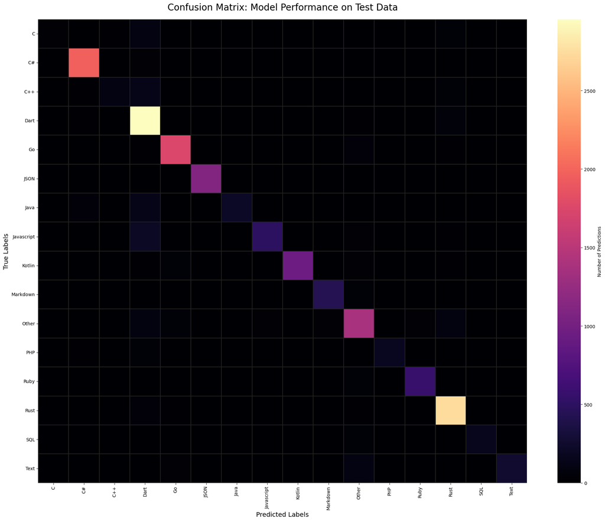

```python
import seaborn as sns

# 1. Setup the figure size (crucial for 40 labels)
plt.figure(figsize=(20, 16))

# 2. Generate the matrix
cm = confusion_matrix(y_test, pred)

# 3. Create the heatmap
# 'rocket_r' or 'viridis' are great for high contrast
# 'annot=False' is recommended for 40 labels to avoid clutter
sns.heatmap(cm,
            annot=False,
            fmt='g',
            cmap='magma',  # High-contrast scale (Dark to Bright Yellow)
            xticklabels=labels,
            yticklabels=labels,
            cbar_kws={'label': 'Number of Predictions'},
            linewidths=0.05,
            linecolor='#222222')

# 4. Refine the typography and layout
plt.title("Confusion Matrix: Model Performance on Test Data", fontsize=20, pad=20)
plt.xlabel("Predicted Labels", fontsize=14)
plt.ylabel("True Labels", fontsize=14)

# Rotate labels so they don't overlap
plt.xticks(rotation=90, fontsize=10)
plt.yticks(rotation=0, fontsize=10)

plt.tight_layout()
plt.show()
```

### NN experiment

Very botched to make the previous code work again :/

```python
device = torch.accelerator.current_accelerator().type if torch.accelerator.is_available() else "cpu"
```

```python
loss_fn = nn.CrossEntropyLoss()

class MyTinyClassifier(nn.Module):
    def __init__(self, input_size, out_size) -> None:
        super().__init__()
        self.linear_relu_stack = nn.Sequential(
            nn.Linear(input_size, 16),
            nn.ReLU(),
            nn.Linear(16, 16),
            nn.ReLU(),
            nn.Linear(16, out_size)
        )

    def forward(self, x):
        return self.linear_relu_stack(x).squeeze(-1)

def train(dataloader: DataLoader, model:MyNN, optimizer: torch.optim.SparseAdam):
    size = len(dataloader.dataset)#type:ignore
    model.train()
    for batch, (X, y) in enumerate(dataloader):
        X, y = X.to(device), y.to(device)

        # Compute prediction error
        pred = model(X)
        loss = loss_fn(pred, y)

        # Backpropagation
        loss.backward()
        optimizer.step()
        optimizer.zero_grad()

        if batch % 200 == 0:
            loss, current = loss.item(), (batch + 1) * len(X)
            print(f"loss: {loss:>7f}  [{current:>5d}/{size:>5d}]")

def test(dataloader: DataLoader, model: MyNN, split: str):
    size = len(dataloader.dataset)#type:ignore
    num_batches = len(dataloader)
    model.eval()
    test_loss, correct = 0, 0
    with torch.no_grad():
        for X, y in dataloader:
            X, y = X.to(device), y.to(device)
            pred = model(X)
            test_loss += loss_fn(pred, y).item()
            correct += (pred.argmax(-1) == y).type(torch.float).sum().item()
    test_loss /= num_batches
    correct /= size
    print(f"{split} Error: \n Accuracy: {(100*correct):>0.1f}%, Avg loss: {test_loss:>8f} \n")

def make_dataloader(X: torch.Tensor, y: ndarray, shuffle = True)-> DataLoader:
    dataset = TensorDataset(X.type(torch.float), torch.from_numpy(y).type(torch.long))
    dataloader = DataLoader(dataset, batch_size=64, shuffle=shuffle)
    return dataloader
```

```python
from sklearn.preprocessing import LabelEncoder

encoder = LabelEncoder()
encoded_labels = encoder.fit_transform(y_train)
dl_prog = make_dataloader(torch.from_numpy(X_train), encoded_labels)
dl_prog_test = make_dataloader(torch.from_numpy(X_test), encoder.transform(y_test), shuffle=False)
```

```python
# device = torch.accelerator.current_accelerator().type
prog_classifer = MyTinyClassifier(X_train.shape[1], len(np.unique(y_test))).to(device)
optimizer = torch.optim.Adam(prog_classifer.parameters(), lr=1e-3)
for t in range(EPOCHS):
    print(f"Epoch {t+1}\n-------------------------------")
    train(dl_prog, prog_classifer,  optimizer)
    test(dl_prog, prog_classifer, "val")
print("Done!")
```

```
Epoch 1
-------------------------------
loss: 2.760884  [   64/68920]
loss: 1.009095  [12864/68920]
loss: 0.879706  [25664/68920]
loss: 0.649387  [38464/68920]
loss: 0.500949  [51264/68920]
loss: 0.805001  [64064/68920]
val Error:
 Accuracy: 82.5%, Avg loss: 0.551308

Epoch 2
-------------------------------
loss: 0.602061  [   64/68920]
loss: 0.415447  [12864/68920]
loss: 0.413219  [25664/68920]
loss: 0.518216  [38464/68920]
loss: 0.299596  [51264/68920]
loss: 0.415766  [64064/68920]
val Error:
 Accuracy: 87.9%, Avg loss: 0.393471

Epoch 3
-------------------------------
loss: 0.250954  [   64/68920]
loss: 0.422872  [12864/68920]
loss: 0.450547  [25664/68920]
loss: 0.346523  [38464/68920]
loss: 0.480793  [51264/68920]
loss: 0.275568  [64064/68920]
val Error:
 Accuracy: 90.2%, Avg loss: 0.315782

Epoch 4
-------------------------------
loss: 0.323184  [   64/68920]
loss: 0.292640  [12864/68920]
loss: 0.331081  [25664/68920]
loss: 0.399156  [38464/68920]
loss: 0.264463  [51264/68920]
```

[output cut: 56 more lines]

```
val Error:
 Accuracy: 94.7%, Avg loss: 0.176292

Epoch 10
-------------------------------
loss: 0.231286  [   64/68920]
loss: 0.124642  [12864/68920]
loss: 0.115084  [25664/68920]
loss: 0.087907  [38464/68920]
loss: 0.218620  [51264/68920]
loss: 0.131659  [64064/68920]
val Error:
 Accuracy: 94.6%, Avg loss: 0.174882

Done!
```

```python
preds = []
size = len(dl_prog_test.dataset)#type:ignore
num_batches = len(dl_prog_test)
prog_classifer.eval()
with torch.no_grad():
    for X, y in dl_prog_test:
        X, y = X.to(device), y.to(device)
        pred = prog_classifer(X)
        preds.append(pred)
preds = torch.cat(preds, 0).argmax(1)
```

```python
preds = encoder.inverse_transform(preds.cpu().numpy())
```

```
Classification report of Random forest (on Test set):
	Accuracy:  93.84%
	Precision:  91.30%
	Recall:  87.36%
	F1-Score:  89.03%
```

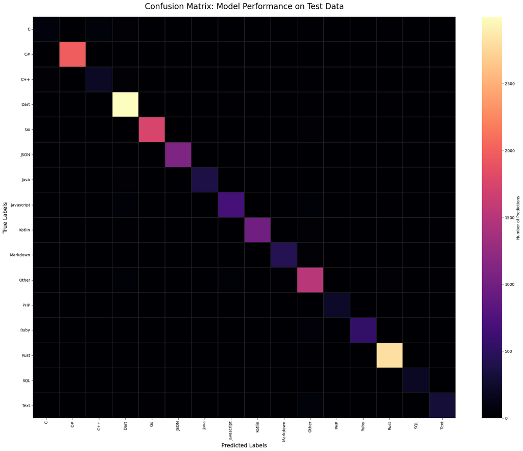

```python
labels=np.unique(y_test)
average = 'macro'

print(f"Classification report of Random forest (on Test set):")
print(f"\tAccuracy:  {accuracy_score(y_test, preds)*100:.2f}%")
print(f"\tPrecision:  {precision_score(y_test, preds, labels=labels, average=average)*100:.2f}%")
print(f"\tRecall:  {recall_score(y_test, preds, labels=labels, average=average)*100:.2f}%")
print(f"\tF1-Score:  {f1_score(y_test, preds, labels=labels, average=average)*100:.2f}%")

# 1. Setup the figure size (crucial for 40 labels)
plt.figure(figsize=(20, 16))

# 2. Generate the matrix
cm = confusion_matrix(y_test, preds)

# 3. Create the heatmap
# 'rocket_r' or 'viridis' are great for high contrast
# 'annot=False' is recommended for 40 labels to avoid clutter
sns.heatmap(cm,
            annot=False,
            fmt='g',
            cmap='magma',  # High-contrast scale (Dark to Bright Yellow)
            xticklabels=labels,
            yticklabels=labels,
            cbar_kws={'label': 'Number of Predictions'},
            linewidths=0.05,
            linecolor='#222222')

# 4. Refine the typography and layout
plt.title("Confusion Matrix: Model Performance on Test Data", fontsize=20, pad=20)
plt.xlabel("Predicted Labels", fontsize=14)
plt.ylabel("True Labels", fontsize=14)

# Rotate labels so they don't overlap
plt.xticks(rotation=90, fontsize=10)
plt.yticks(rotation=0, fontsize=10)

plt.tight_layout()
plt.show()
```